# Analyzing Spotify’s Features

Hsin-Pan Chen, Sreeya Gudlavalleti, Kaito Minami, Regina Rabkina, Luana Siyoum

2024-03-19

## 1.R Markdown

R Markdown is a framework that combines code, the results/outputs of the code, and comments into a file (Garrett Grolemund and Hadley Wickham, 2017). Specifically, this file is a simple and easy to use plain text file that has the extension .Rmd. These documents are reproducible in various ways such as a report, publication, and web pages and support various output formats such as HTML, PDFs, MS Word, etc. You can break down an R Markdown file into three types of content. One, there’s a YAML header that includes information such as title, author, date, and output. Second, there are chunks of R code, and third, there is text mixed with text formatting such as “#” headings. R Markdown is not only useful for writing code and communicating to others who are interested in the reasoning behind the code but also decision makers who want to focus on the conclusions and not necessarily the code itself (Garrett Grolemund and Hadley Wickham, 2017). It captures both what code you wrote and the thinking behind it in an elegant format to build a cohesive narrative for effective communication (RStudio, 2020). It is especially useful since you can combine the R code, results from the data analysis (including plots and tables) and written comments into a single nicely formatted document.

## 2. Tidyverse

Rows:

- filter(): allows users to subset data based on specific criteria. You can filter rows to include only observations that meet specific criteria (“Introduction to dplyr”). For example, you can filter a dataset to only include entries of individuals above a certain age. This function enables the targeted withdrawal of relevant information for analysis.
- arrange(): “works similarly to filter() except that instead of filtering or selecting rows, it reorders them. It takes a data frame, and a set of column names (or more complicated expressions) to order by” (“Introduction to dplyr”). This function is useful for arranging data in ascending/descending order and facilitates analysis by allowing users to rank observations or sort data chronologically.

Columns:

- select(): users can choose specific variables (columns) from a dataset, allowing them to focus on relevant aspects of the data for analysis (“Introduction to dplyr”). This keeps your data frame focused and reduces clutter, streamlining data handling and exploring relationships between variables.
- group_by(): used to group data by one or more variables (“Group by function”). This function is useful when you want to analyze data subsets based on a shared characteristic.

Groups of Rows:

- summarize(): used to calculate summary statistics within each group (“Introduction to dplyr”), such as mean, median, and mode. This helps identify central tendencies and variability within categories.

The functions ‘group_by()’ and ‘summarize()’ work together for efficient aggregation and summarization of data, giving users insight into group-level trends. Overall, these functions in Tidyverse allow for efficient workflow for data manipulation and analysis.

## 3. Load the data set, load the libraries, and use filter, select, arrange, group_by, summarize

```r
#Load the libraries & packages
library(readr)
library(skimr)
library(tidyverse)
library(tidyr)

# Question 3
# Load the dataset
spotify <- read_csv("SpotifyFeatures.csv")
# Using filter() to filter
filter_song <- spotify %>%
  filter(genre == "Pop" & danceability > 0.8 & tempo > 125)
filter_song
```

```
## # A tibble: 465 × 18
##    genre artist_name    track_name track_id popularity acousticness danceability
##    <chr> <chr>          <chr>      <chr>         <dbl>        <dbl>        <dbl>
##  1 Pop   Travis Scott   SICKO MODE 2xLMifQ…         94      0.00513        0.834
##  2 Pop   Khalid         Talk       0rTV5We…         94      0.0501         0.9
##  3 Pop   Jonas Brothers Sucker     4y3OI86…         94      0.0436         0.846
##  4 Pop   Ariana Grande  bad idea   5Il6Oe7…         91      0.0268         0.847
##  5 Pop   21 Savage      a lot      2t8yVaL…         93      0.0395         0.837
##  6 Pop   Cardi B        I Like It  58q2HKr…         90      0.099          0.816
##  7 Pop   Travis Scott   goosebumps 6gBFPUF…         86      0.0847         0.841
##  8 Pop   Offset         Legacy (f… 7pMRoGL…         85      0.178          0.844
##  9 Pop   Pedro Capó     Calma - R… 5iwz1Ni…         97      0.323          0.826
## 10 Pop   Lil Baby       Pure Coca… 577YBGu…         86      0.00127        0.964
## # ℹ 455 more rows
## # ℹ 11 more variables: duration_ms <dbl>, energy <dbl>, instrumentalness <dbl>,
## #   key <chr>, liveness <dbl>, loudness <dbl>, mode <chr>, speechiness <dbl>,
## #   tempo <dbl>, time_signature <chr>, valence <dbl>
```

```r
# Using select() to select some variable
sel_data <- spotify %>%
  select(artist_name, track_name, popularity)
sel_data
```

```
## # A tibble: 232,725 × 3
##    artist_name         track_name                                     popularity
##    <chr>               <chr>                                               <dbl>
##  1 Henri Salvador      C'est beau de faire un Show                             0
##  2 Martin & les fées   Perdu d'avance (par Gad Elmaleh)                        1
##  3 Joseph Williams     Don't Let Me Be Lonely Tonight                          3
##  4 Henri Salvador      Dis-moi Monsieur Gordon Cooper                          0
##  5 Fabien Nataf        Ouverture                                               4
##  6 Henri Salvador      Le petit souper aux chandelles                          0
##  7 Martin & les fées   Premières recherches (par Paul Ventimila, Lor…          2
##  8 Laura Mayne         Let Me Let Go                                          15
##  9 Chorus              Helka                                                   0
## 10 Le Club des Juniors Les bisous des bisounours                              10
## # ℹ 232,715 more rows
```

We are trying to select the artist_name, track_name, and popularity columns. This will contain only the artist name, track name, and the song’s popularity, making it easier to analyze these specific aspects without the effect of other variables.

```r
# Using arrange()
arr_data <- spotify %>%
  arrange(popularity)
arr_data
```

```
## # A tibble: 232,725 × 18
##    genre artist_name    track_name track_id popularity acousticness danceability
##    <chr> <chr>          <chr>      <chr>         <dbl>        <dbl>        <dbl>
##  1 Movie Henri Salvador C'est bea… 0BRjO6g…          0      0.611          0.389
##  2 Movie Henri Salvador Dis-moi M… 0Gc6TVm…          0      0.703          0.24
##  3 Movie Henri Salvador Le petit … 0Mf1jKa…          0      0.749          0.578
##  4 Movie Chorus         Helka      0ST6uPf…          0      0.00104        0.734
##  5 Movie Leopold Stoko… Symphony … 0XKgego…          0      0.921          0.191
##  6 Movie Richard M. Sh… Keys of L… 0pXwl2C…          0      0.97           0.4
##  7 Movie Michel Roux    Les avent… 0uWUjxM…          0      0.548          0.588
##  8 Movie Jean Claude C… Diane      0vS7Zid…          0      0.7            0.625
##  9 Movie Jean Claude C… Pourquoi … 15CpJP0…          0      0.669          0.707
## 10 Movie Jean Piat      Comme min… 16UTNMh…          0      0.882          0.711
## # ℹ 232,715 more rows
## # ℹ 11 more variables: duration_ms <dbl>, energy <dbl>, instrumentalness <dbl>,
## #   key <chr>, liveness <dbl>, loudness <dbl>, mode <chr>, speechiness <dbl>,
## #   tempo <dbl>, time_signature <chr>, valence <dbl>
```

This example arranges the dataset by popularity in default of ascending order. Organizing the dataset in ascending order based on the popularity score, allows people to easily review songs from the least to the most popular.

```r
# Using arrange(desc())
arr_descdata <- spotify %>%
  arrange(desc(popularity))
arr_descdata
```

```
## # A tibble: 232,725 × 18
##    genre    artist_name track_name track_id popularity acousticness danceability
##    <chr>    <chr>       <chr>      <chr>         <dbl>        <dbl>        <dbl>
##  1 Dance    Ariana Gra… 7 rings    14msK75…        100       0.578         0.725
##  2 Pop      Ariana Gra… 7 rings    14msK75…        100       0.578         0.725
##  3 Dance    Ariana Gra… break up … 4kV4N9D…         99       0.0421        0.726
##  4 Rap      Post Malone Wow.       6MWtB6i…         99       0.163         0.833
##  5 Pop      Ariana Gra… break up … 4kV4N9D…         99       0.0421        0.726
##  6 Pop      Post Malone Wow.       6MWtB6i…         99       0.163         0.833
##  7 Hip-Hop  Daddy Yank… Con Calma  5w9c2J5…         98       0.11          0.737
##  8 Pop      Daddy Yank… Con Calma  5w9c2J5…         98       0.11          0.737
##  9 Reggaet… Daddy Yank… Con Calma  5w9c2J5…         98       0.11          0.737
## 10 Dance    Halsey      Without Me 5p7ujcr…         97       0.297         0.752
## # ℹ 232,715 more rows
## # ℹ 11 more variables: duration_ms <dbl>, energy <dbl>, instrumentalness <dbl>,
## #   key <chr>, liveness <dbl>, loudness <dbl>, mode <chr>, speechiness <dbl>,
## #   tempo <dbl>, time_signature <chr>, valence <dbl>
```

This example arranges the dataset by popularity in descending order. Organizing the dataset in descending order based on the popularity score, allows people to easily review songs from the most popular to the least.

```r
# Using group_by and summarize with the mean function:
avg_danceability <- spotify %>%
  group_by(genre) %>%
  summarize(avg_danceability = mean(danceability, na.rm = TRUE))
avg_danceability
```

```
## # A tibble: 27 × 2
##    genre            avg_danceability
##    <chr>                       <dbl>
##  1 A Capella                   0.412
##  2 Alternative                 0.542
##  3 Anime                       0.472
##  4 Blues                       0.528
##  5 Children's Music            0.697
##  6 Children’s Music            0.542
##  7 Classical                   0.306
##  8 Comedy                      0.559
##  9 Country                     0.577
## 10 Dance                       0.638
## # ℹ 17 more rows
```

This example shows calculating the average danceability by genre. This function groups the songs by their genre and calculates the mean danceability score, helping identify which genres tend to produce more danceable music on average.

```r
# Using group_by and summarize with the median function:
med_tempo <- spotify %>%
  group_by(genre) %>%
  summarize(med_tempo = median(tempo, na.rm = TRUE))
med_tempo
```

```
## # A tibble: 27 × 2
##    genre            med_tempo
##    <chr>                <dbl>
##  1 A Capella            110.
##  2 Alternative          120.
##  3 Anime                128.
##  4 Blues                118.
##  5 Children's Music     119.
##  6 Children’s Music     120.
##  7 Classical             97.1
##  8 Comedy                90.1
##  9 Country              123.
## 10 Dance                120.
## # ℹ 17 more rows
```

This example shows calculating the median tempo by genre. This function groups the songs by their genre and calculates the median tempo, helping to show the typical tempo associated with different genres. This might potentially reveal genre-specific tempo trends.

## 4. Interpret arrange() and arrange(desc()) function

Using the function of arrange() and arrange(desc()) enables to organization of data, making it more interpretable and insightful. By using arrange(), we can sort data in ascending order based on specified variables, which helps to manage and analyze the dataset to quickly find the valued insight behind the dataset. arrange(desc()) sorts data in descending order, similar to arranging data, but in the opposite order (R Coder, 2024). Applying these functions to a dataset of Spotify tracks data, and observing variables such as popularity in order, can reveal trends and outliers that were not immediately apparent within the unorganized dataset. For instance, arranging songs by popularity in ascending order might highlight unpopular tracks, offering insights to artists, whereas, sorting them in descending order brings the most popular one to the top, which could be useful for understanding current music trends or what makes a song successful in the public. I think these functions help to highlight the data in a way that can provide the patterns or questions that might not have been considered before at the beginning of the unorganized dataset. These functions would guide us to more detailed analysis informing strategic decisions in music marketing or even predicting future trends.

## 5. skim() function and percentiles

To understand the significance of percentiles it’s important to define it first. Percentiles represent the position of a data point within a dataset by denoting the percentage of the dataset below that numerical observation (Stephen Eldridge, 2024). Therefore, they are important for knowing where a data point falls within the distribution of a dataset. Certain percentiles specifically have special significance. For example, the 50th percentile, also known as the second quartile, represents the median of a dataset. In addition, the 25th percentile is signified as the first (or lower) quartile and the 75th percentile represents the third (or upper) quartile. These specific percentiles are especially important because they are often used as part of a “five-number summary” which helps in knowing the distribution of a dataset in data analysis. These percentiles are also useful for creating box plots which further help in understanding the distribution of the dataset (Penn State University). The lengths of the box plots, which are determined with information from percentiles, give insights into the variation in the dataset. After determining the percentiles, you can also discover further important statistical information such as any outliers there may be. Using the skim() function, you can determine the percentiles of different variables in the dataset. For example, in the spotify dataset the 50th percentile, or median, of the popularity variable is 43. This tells us that 50% of the dataset has a popularity below 43. It can also be important to put this more into context. For instance, the popularity variable ranges from 0 to 100, which is indicated as the 0th percentile (or minimum) and 100th percentile (or maximum) respectively from the skim() function results. Then knowing the median is 43 you can interpret that half the songs in the dataset is relatively low in comparison to how much popularity they could have.

```r
# Question 5
# Using the skim function on the dataset
skim(spotify)
```

Data summary

| Name | spotify |
| --- | --- |
| Number of rows | 232725 |
| Number of columns | 18 |
| _______________________ |  |
| Column type frequency: |  |
| character | 7 |
| numeric | 11 |
| ________________________ |  |
| Group variables | None |

**Variable type: character**

| skim_variable | n_missing | complete_rate | min | max | empty | n_unique | whitespace |
| --- | --- | --- | --- | --- | --- | --- | --- |
| genre | 0 | 1 | 3 | 16 | 0 | 27 | 0 |
| artist_name | 0 | 1 | 1 | 84 | 0 | 14564 | 0 |
| track_name | 0 | 1 | 1 | 292 | 0 | 148608 | 0 |
| track_id | 0 | 1 | 22 | 22 | 0 | 176774 | 0 |
| key | 0 | 1 | 1 | 2 | 0 | 12 | 0 |
| mode | 0 | 1 | 5 | 5 | 0 | 2 | 0 |
| time_signature | 0 | 1 | 3 | 5 | 0 | 5 | 0 |

**Variable type: numeric**

| skim_variable | n_missing | complete_rate | mean | sd | p0 | p25 | p50 | p75 | p100 | hist |
| --- | --- | --- | --- | --- | --- | --- | --- | --- | --- | --- |
| popularity | 0 | 1 | 41.13 | 18.19 | 0.00 | 29.00 | 43.00 | 55.00 | 100.00 | ▃▆▇▂▁ |
| acousticness | 0 | 1 | 0.37 | 0.35 | 0.00 | 0.04 | 0.23 | 0.72 | 1.00 | ▇▂▂▂▃ |
| danceability | 0 | 1 | 0.55 | 0.19 | 0.06 | 0.44 | 0.57 | 0.69 | 0.99 | ▂▃▇▇▂ |
| duration_ms | 0 | 1 | 235122.34 | 118935.91 | 15387.00 | 182857.00 | 220427.00 | 265768.00 | 5552917.00 | ▇▁▁▁▁ |
| energy | 0 | 1 | 0.57 | 0.26 | 0.00 | 0.38 | 0.60 | 0.79 | 1.00 | ▃▅▇▇▇ |
| instrumentalness | 0 | 1 | 0.15 | 0.30 | 0.00 | 0.00 | 0.00 | 0.04 | 1.00 | ▇▁▁▁▁ |
| liveness | 0 | 1 | 0.22 | 0.20 | 0.01 | 0.10 | 0.13 | 0.26 | 1.00 | ▇▂▁▁▁ |
| loudness | 0 | 1 | -9.57 | 6.00 | -52.46 | -11.77 | -7.76 | -5.50 | 3.74 | ▁▁▁▇▇ |
| speechiness | 0 | 1 | 0.12 | 0.19 | 0.02 | 0.04 | 0.05 | 0.10 | 0.97 | ▇▁▁▁▁ |
| tempo | 0 | 1 | 117.67 | 30.90 | 30.38 | 92.96 | 115.78 | 139.05 | 242.90 | ▁▇▆▂▁ |
| valence | 0 | 1 | 0.45 | 0.26 | 0.00 | 0.24 | 0.44 | 0.66 | 1.00 | ▇▇▇▆▃ |

## 6. Monte Carlo simulation

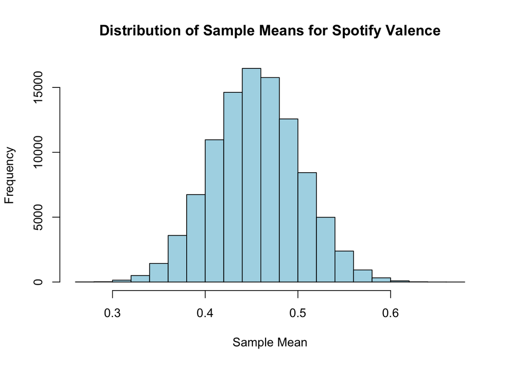

```r
# Question 6
# Initializing samples
num_samples <- 100000
sample_size <- 30
valence <- spotify$valence

#  Sample means and sample standard deviation lists
sample_means <- numeric(num_samples)
sample_std_devs <- numeric(num_samples)

# Collects sample means and sample standard deviation stats for 100,000 times
for(i in 1:num_samples){
  sample <- sample(valence, sample_size, replace = FALSE)
  sample_means[i] <- mean(sample)
  sample_std_devs[i] <- sd(sample)
}

# Sample means histogram
hist(sample_means, main = "Distribution of Sample Means for Spotify Valence", xlab = "Sample Mean", col = "lightblue", border = "black")
```

```r
# Check the population mean value
pop_mean = spotify %>%
  summarize(mean(valence))
pop_mean
```

```
## # A tibble: 1 × 1
##   `mean(valence)`
##             <dbl>
## 1           0.455
```

We applied the Monte Carlo simulation in this section with the target numerical variable “valence,” employing a sample size of 30 and conducting 100,000 iterations. By running random simulations, Monte Carlo methods offer insights into the variability of statistical measures, providing valuable information for decision-making processes. Valence variable we target, according to a Spotify Features dataset documentation, is a value to quantify the happiness mood conveyed by a song, with higher the valence delivering a happier tone to the audience. The dataset has the population mean value of 0.455, which this simulation covers well as the highest bar is around the value of 0.455. Moreover, the bar tends to be taller around the center, creating a beautiful bell-shaped curve centering around the 0.455 as a result. When the mean values align well, it indicates that we have gathered enough sample size to mimic the population mean pattern with our simulated sample mean. The bell-shaped curve is a sign of normal distribution to statistically imitate the population curve. As noted, the taller bar, indicating more data points, is concentrated around the center sample mean value, so I could conclude that it has low variability and is narrower. This means that there is more likelihood to correctly predict the population mean by taking sample means in this method. The sample mean valence graph is more bell-shaped than the population mean valence graph, because the sample mean graph is essentially a group of mean values, processed by summation, division, and clustering of summarized values, but the population mean graph is only a frequency count of raw data. Surpassing the sample size of 30, this is also known as Central Limit Theorem, allowing statisticians easier statistical analysis and inference, convenient to prepare for the advanced statistical techniques that assume normal distribution. In essence, the Monte Carlo simulation technique, coupled with the analysis of the valence variable, has provided valuable insights into the statistical patterns inherent in Spotify data. By faithfully replicating the population mean pattern and showcasing a bell-shaped curve indicative of normal distribution, this simulation has facilitated a deeper understanding of the dataset’s characteristics. Moreover, the comparative analysis between sample mean and population mean graphs underscores the efficacy of utilizing sample means in predicting population parameters accurately. Overall, this simulation serves as a robust analytical tool for exploring and interpreting complex datasets, offering valuable implications for further research and application in diverse domains.

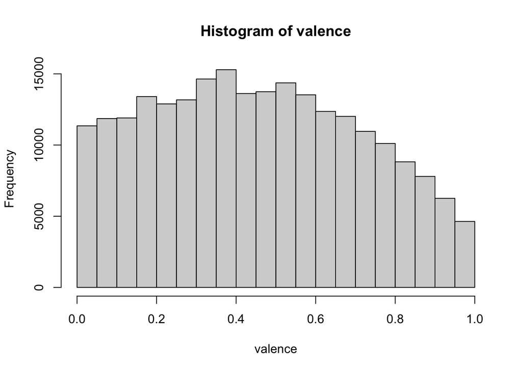

```r
# Check the population histogram
hist(valence)
```

## 7. Standard error

```r
# Question 7
# Calculate standard error of the mean, which is the standard deviation of the sample means
standard_error_1 <- sd(sample_means)

# From each sample we can calculate an estimated standard error
# The average of these should be very close to the standard error calculated above
sample_std_errors <- sample_std_devs/sqrt(sample_size)
head(sample_std_errors)
```

```
## [1] 0.05019439 0.05109988 0.05759072 0.04851906 0.04866004 0.04089567
```

```r
standard_error_2 <- mean(sample_std_errors)

# Print the standard error
# Standard error of the mean
cat("Standard Error 1:", standard_error_1, "\n")
```

```
## Standard Error 1: 0.04745257
```

```r
#Standard error for the samples
cat("Standard Error 2:", standard_error_2, "\n")
```

```
## Standard Error 2: 0.04729344
```

## 8. Confidence Interval and T-Test

```r
# Question 8

# Calculating the Confidence Interval
# Confidence  Interval = population mean +- critical value * sample standard error
population_mean <- mean(valence)  # Use the actual mean from the dataset
ci_lower_bound <- sample_means - 2.042 * sample_std_errors
ci_upper_bound <- sample_means + 2.042 * sample_std_errors
counts <- 100 * mean(ci_lower_bound < population_mean & population_mean < ci_upper_bound)

cat("The confidence interval contains the population mean", counts, "percent of the time\n")
```

```
## The confidence interval contains the population mean 94.894 percent of the time
```

## 9. P-value

P-value is a statistical measure used in hypothesis testing to help decide whether to reject the null hypothesis. It is used to validate a hypothesis against observed data and helps researchers assess whether the observed data supports or contradicts the null hypothesis. A null hypothesis states that there is no difference between the two variables that are being studied which means that one variable does not affect the other (Beers 2024.). P-values come from comparing the observed value to a reference value, considering the probability distribution of the statistic. A bigger difference between these values leads to a smaller p-value (Beers n.d.). Statistical significance is usually shown with a p-value from 0 to 1. The smaller the p-value is the more likely you are to reject the null hypothesis. A p-value less than or equal to a set level, like 0.05 or 0.01, shows that the result is statistically significant. This means there’s good evidence against the null hypothesis. For example, if we choose α = 0.05, we reject the null hypothesis when the p-value is ≤ 0.05. This suggests strong evidence against the null hypothesis, with less than a 5% chance that the results are random. So, we reject the null hypothesis and support the alternative hypothesis instead (Mcleod 2023). The type of statistical test we use affects how we calculate the p-value. There are three main types of tests: lower-tailed, upper-tailed, and two-tailed tests (Beers n.d.). In a lower-tailed test, we’re interested in seeing if our result is significantly lower than what we expect, while an upper-tailed test checks if our result is significantly higher. On the other hand, a two-tailed test looks at whether our result is significantly different from what we expect in any direction, either higher or lower. These distinctions help us interpret the significance of our data and determine if the observed differences are due to real effects or simply due to random chance (Mcleod 2023).

## 10. Check the Central Limit Theorem

According to the Central Limit Theorem, as the sample size approaches infinity, the distribution of sample means becomes increasingly close to a normal distribution regardless of the shape of the population distribution. This is exactly what is happening in this case. With the sample size of 1 we see that the histogram is skewed and does not have the shape of the bell curve. But as the sample size increases it is more symmetrical and is a bell curve shape and close to a normal distribution.

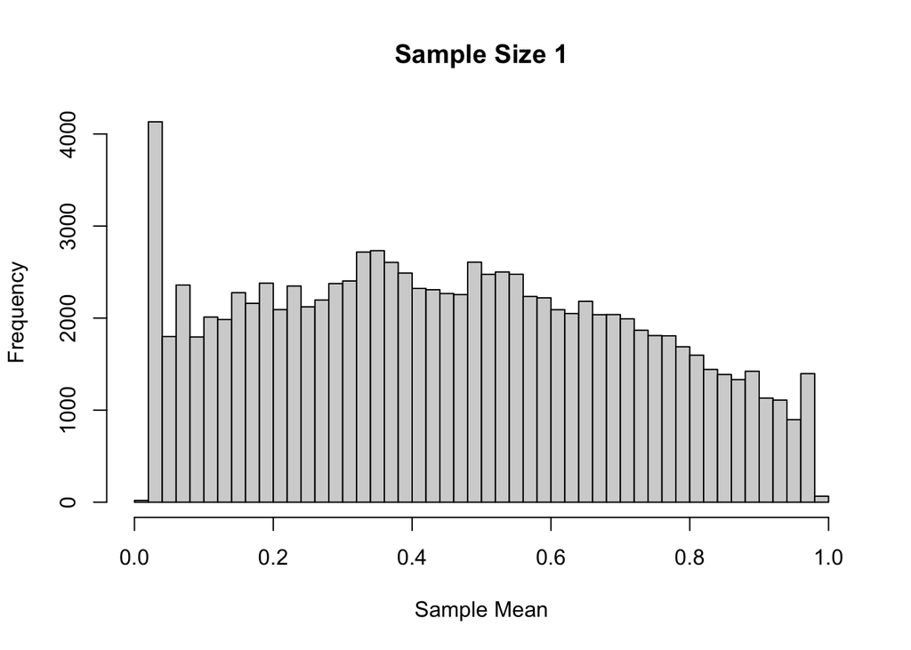

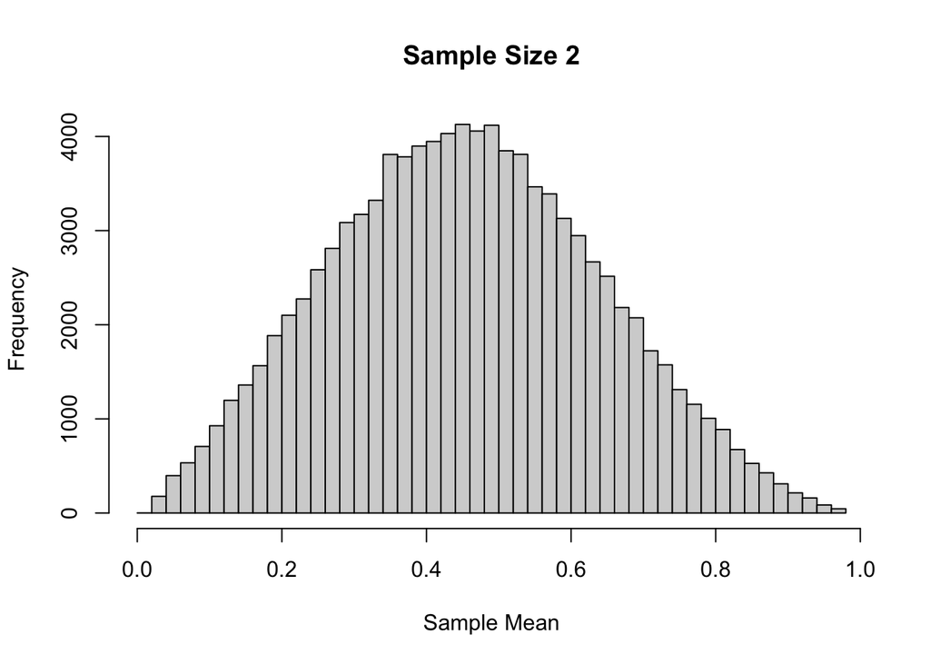

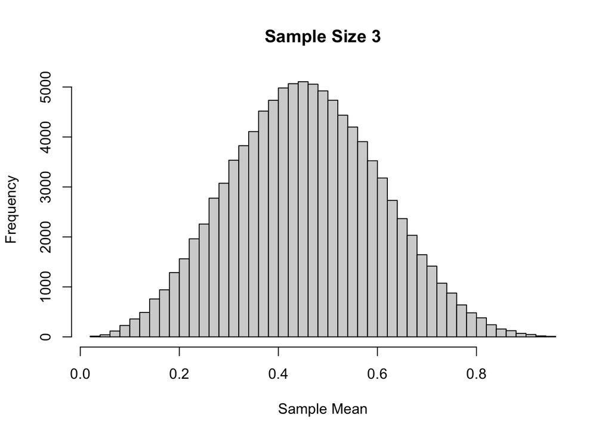

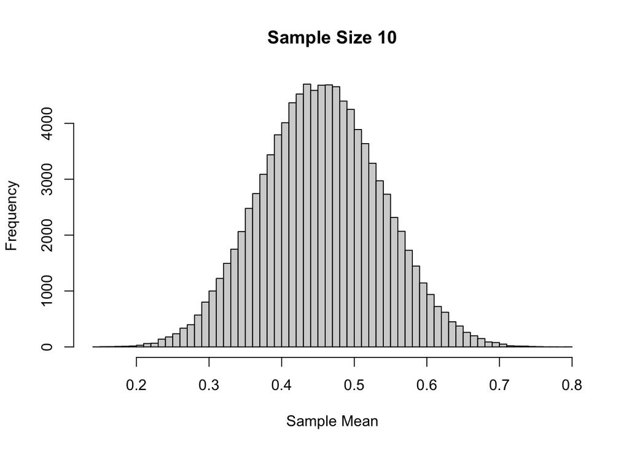

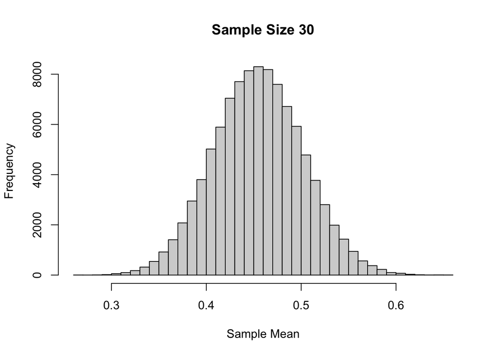

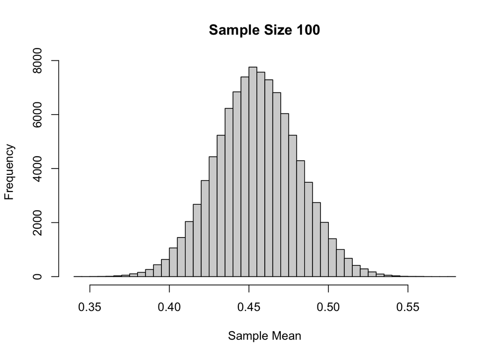

```r
# Question 10
# This gets the valence
num_value <- spotify$valence


# This gets the mean and puts the sample size into a list
population_mean <- mean(num_value)
population_size <- length(num_value)
sample_sizes <- c(1, 2, 3, 10, 30, 100)
num_iterations <- 100000

# This goes through the different sample sizes and plots them
for (size in sample_sizes) {
  sample_means <- replicate(num_iterations, mean(sample(num_value, size=size)))

  hist(sample_means, breaks=50, main=paste("Sample Size", size),
       xlab="Sample Mean", ylab="Frequency")
}
```

## References

3.4 - five useful numbers (percentiles): Stat 100. PennState: Statistics Online Courses. (n.d.). https://online.stat.psu.edu/stat100/lesson/3/3.4  
Beers, Brain. n.d. “P-Value: What It Is, How to Calculate It, and Why It Matters.” Investopedia. Accessed March 19, 2024. https://www.investopedia.com/terms/p/p-value.asp#:~:text=The%20calculation%20for%20a%20p.

Eldridge, S. (2024, February 28). Percentile. Encyclopædia Britannica. https://www.britannica.com/topic/percentile

Grolemund, H. W. and G. (2017). R for data science. 27 R Markdown. https://r4ds.had.co.nz/r-markdown.html#:~:text=R%20Markdown%20provides%20an%20unified,files%2C%20slideshows%2C%20and%20more

GeeksforGeeks. (2021, August 31). Group by function in R using Dplyr. GeeksforGeeks. https://www.geeksforgeeks.org/group-by-function-in-r-using-dplyr/

Introduction to dplyr. The Comprehensive R Archive Network. (n.d.). https://cran.r-project.org/web/packages/dplyr/vignettes/dplyr.html

Mcleod, Saul. (2023). “P-Values and Statistical Significance.” Simply Psychology. October 13, 2023. https://www.simplypsychology.org/p-value.html.

Order rows in R with the arrange() function from dplyr. RCODER. (2024, January 25). https://r-coder.com/arrange-dplyr-r/

R markdown. R Markdown. (2020). https://rmarkdown.rstudio.com/

Wheelan, C. (2012, December 31). Naked statistics- stripping the dread from the data by.Charles Wheelan Urdukutabkhanapk -. Studocu. https://www.studocu.com/en-us/document/baruch-college-cuny/statistical-analysis-for-economics-and-finance/naked-statistics-stripping-the-dread-from-the-data-bycharles-wheelan-urdukutabkhanapk/62751794